# Predicting School Dropout in Developing Countries

A Machine Learning Approach with Policy Simulations Using Longitudinal Data from India and Peru

Authors

Jasnoor Anand

Sanaa Kashif

Mehria Saadat Khan

Published

December 21, 2025

## 0.1 Executive Summary

This study investigates predictors of school dropout among adolescents in India and Peru using longitudinal data from the Young Lives study (Young Lives, n.d.). We employ a mixed-methods approach combining logistic regression, machine learning with class imbalance techniques, and policy simulation through sensitivity analysis.

**Sample:** We analyze 1,678 children with complete data from both Round 3 (age ~8) and Round 4 (age ~12), drawn from an initial sample of 3,874 children. High study attrition (55.5%) limits generalizability, but our complete case analysis provides valid estimates for children who remained in the study.

# 1 Introduction

## 1.1 Motivation and Policy Context

Education is widely recognized as a fundamental driver of economic development and social mobility (Ozturk, 2001). While global primary school enrollment rates have reached historic highs, with nearly 90% of children worldwide attending primary school, keeping children in school through adolescence remains a significant challenge in developing countries (UNESCO, 2021). The transition from primary to secondary education represents a critical juncture where dropout rates spike, particularly in low and middle-income countries (UNICEF, 2022).

Understanding what predicts school dropout is not just an academic exercise. It has direct implications for how governments and NGOs allocate resources. Should we invest more in nutrition programs? Cash transfers to reduce household economic stress? Family planning initiatives? The answer depends on which factors actually drive dropout decisions, and more importantly, how much changing those factors would matter.

## 1.2 Research Questions

This study addresses three interconnected questions:

1. **Prediction**: What factors best predict which children will drop out of school between ages 8 and 12 in India and Peru?
2. **Methodology**: How can we build effective predictive models when the outcome (dropout) is rare, affecting only 1-2% of our sample?
3. **Policy simulation**: If we could intervene to change modifiable risk factors like nutrition or household size, how much would predicted dropout rates change?

## 1.3 Contribution

This project makes several contributions:

**Methodologically**, we demonstrate how to handle severe class imbalance in a policy-relevant context, comparing parametric and machine learning approaches. We show that standard techniques fail with rare outcomes, but specialized methods (class weighting, balanced forests) can extract meaningful patterns.

**Substantively**, we provide evidence on the relative importance of different risk factors for adolescent dropout in two major developing countries. Our sensitivity analysis translates statistical associations into predicted policy impacts, offering a template for evidence-based decision making.

**Technically**, we showcase best practices in reproducible data science, including proper longitudinal data merging, handling of study attrition, and transparent documentation of all analytical decisions.

# 2 Data

## 2.1 The Young Lives Study

We use data from Young Lives, a longitudinal study tracking children in four developing countries (Ethiopia, India, Peru, and Vietnam) from early childhood through young adulthood. The study began in 2001-2002 and has conducted five rounds of data collection. Young Lives is one of the most comprehensive longitudinal datasets available on child development in the Global South, making it ideal for studying educational trajectories.

For this analysis, we focus on the **Younger Cohort** in **India and Peru** - children born around 2001-2002 who were surveyed at: -

- **Round 3 (2009)**: Age approximately 8 years old
- **Round 4 (2013)**: Age approximately 12 years old

We chose these two countries because they represent different geographic and cultural contexts within the developing world, allowing us to examine whether patterns are consistent across settings (UK Data Service, n.d.).

## 2.2 Sample Construction and Attrition

Our sample construction involved several steps:

### 2.2.1 Initial Sample

- **India Round 3**: 1,931 children - **Peru Round 3**: 1,943 children - **Total Round 3**: 3,874 children

### 2.2.2 Study Attrition

A major challenge in longitudinal research is attrition: participants who are surveyed in one round but cannot be found or decline to participate in subsequent rounds. In our data:

- **India**: 1,066 children (55.2%) surveyed in Round 3 have missing Round 4 data
- **Peru**: 1,085 children (55.8%) surveyed in Round 3 have missing Round 4 data
- **Total attrition**: 2,151 children (55.5%)

This high attrition rate is concerning but not unusual for longitudinal studies in developing countries where families are highly mobile. Attrition can bias results if children who drop out of the study are systematically different from those who remain (Alderman et al., 2001). We discuss this limitation in detail later.

### 2.2.3 Analytical Sample

After accounting for attrition and missing data on key variables:

- **Children with Round 4 data available**: 1,723 (44.5% retention from Round 3)
- **Children with complete predictor data**: 1,678 (our final analytical sample)
- **Dropout cases in analytical sample**: 21 children (1.25%)

We use **complete case analysis**, including only the 1,678 children with complete information on all predictor variables. This approach is appropriate given minimal missing data (<3% for most variables).

Sample Composition and Attrition by Country

| Country | Round 3 Total | Round 4 Available | Missing Round 4 | Attrition Rate |
| --- | --- | --- | --- | --- |
| India | 1931 | 865 | 1066 | 55.2% |
| Peru | 1943 | 858 | 1085 | 55.8% |
| Combined | 3874 | 1723 | 2151 | 55.5% |

## 2.3 Outcome Variable: Dropout

We define **dropout** as a binary outcome comparing a child’s enrollment status between Round 3 and Round 4.

**A child is coded as:**

- **Dropout = 1**: Enrolled at Round 3 but NOT enrolled at Round 4
- **Dropout = 0**: Enrolled at both Round 3 and Round 4 (stayed in school)
- **Dropout = Missing**: Cannot determine status (not enrolled at R3 or missing R4 data)

This conservative definition captures true dropout among successfully enrolled children.

### 2.3.1 Dropout Rates

Dropout Rates in Analytical Sample

| Country | Sample Size | Dropouts | Dropout Rate |
| --- | --- | --- | --- |
| India | 844 | 19 | 2.25% |
| Peru | 834 | 2 | 0.24% |
| Combined | 1678 | 21 | 1.25% |

**Key observations:**

- **Overall dropout rate**: 1.25% (21 dropouts among 1,678 children in analytical sample)
- **Low dropout rate** presents a significant **class imbalance challenge** for predictive modeling
- Standard ML algorithms struggle with rare outcomes, they can achieve 98.75% accuracy by simply predicting “no dropout” for everyone

## 2.4 Predictor Variables

We selected five key predictor variables based on prior literature on educational attainment in developing countries and data availability:

### 2.4.1 1. Body Mass Index (BMI)

**Rationale**: Nutrition and health status affect children’s ability to attend and succeed in school. Malnutrition is associated with fatigue, illness, and cognitive difficulties (Bisset et al., 2012).

**Measurement**: Continuous variable, calculated from measured height and weight.

**Policy relevance**: School feeding programs, nutrition supplementation.

### 2.4.2 2. Household Size

**Rationale**: Larger households mean more competition for resources and potentially more pressure for older children to work or care for siblings (Francess et al., 2017).

**Measurement**: Count of household members.

**Policy relevance**: Family planning programs, household support services.

### 2.4.3 3. Wealth Index

**Rationale**: Economic constraints are a primary driver of dropout, as poor families may need children to work or cannot afford school-related costs (Wangu et al., 2024).

**Measurement**: Composite index based on household assets, housing quality, and access to services. Higher values indicate greater wealth.

**Policy relevance**: Cash transfer programs, poverty reduction initiatives.

### 2.4.4 4. Math Score

**Rationale**: Academic performance is both a predictor and early warning sign of dropout risk. Children who struggle academically are more likely to disengage (National Dropout Prevention Center/Network, 2002).

**Measurement**: Standardized test score from Round 3 assessments.

**Policy relevance**: Remedial education, tutoring programs, early intervention systems.

### 2.4.5 5. Height-for-Age Z-Score (ZHFA)

**Rationale**: Stunting (low height-for-age) reflects chronic malnutrition and poor early childhood conditions, with lasting effects on cognitive development (Gansaonré et al., 2021).  
**Measurement**: Z-score calculated relative to WHO growth standards. Negative values indicate stunting.

**Policy relevance**: Early childhood nutrition, maternal health programs.

### 2.4.6 Descriptive Statistics

Descriptive Statistics for Predictor Variables

| Variable | N | Mean | SD | Min | Median | Max |
| --- | --- | --- | --- | --- | --- | --- |
| BMI | 1678 | 15.28 | 2.32 | 4.58 | 15.02 | 41.36 |
| Household Size | 1678 | 5.29 | 1.94 | 2.00 | 5.00 | 23.00 |
| Math Score | 1678 | 13.41 | 6.05 | 0.00 | 14.00 | 29.00 |
| Wealth Index | 1678 | 0.53 | 0.20 | 0.01 | 0.55 | 0.95 |
| Height-for-Age Z-Score | 1678 | -1.19 | 1.13 | -11.02 | -1.22 | 12.02 |

### 2.4.7

```r
#| label: missing-data
#| echo: false
#| tbl-cap: "Missing Data on Predictor Variables"

missing_summary <- data %>%
  summarise(
    BMI = sum(is.na(bmi)),
    `Household Size` = sum(is.na(hhsize)),
    `Wealth Index` = sum(is.na(wi)),
    `Math Score` = sum(is.na(math)),
    `Height-for-Age Z-Score` = sum(is.na(zhfa))
  ) %>%
  pivot_longer(everything(), names_to = "Variable", values_to = "Missing") %>%
  mutate(
    Total = nrow(data),
    Missing_Pct = round(Missing / Total * 100, 1)
  )

kable(missing_summary,
      col.names = c("Variable", "Missing (N)", "Total", "Missing (%)"))
```

| Variable | Missing (N) | Total | Missing (%) |
| --- | --- | --- | --- |
| BMI | 8 | 3874 | 0.2 |
| Household Size | 0 | 3874 | 0.0 |
| Wealth Index | 10 | 3874 | 0.3 |
| Math Score | 86 | 3874 | 2.2 |
| Height-for-Age Z-Score | 7 | 3874 | 0.2 |

**Missing data is minimal** for our key variables (all under 3%), allowing us to use complete case analysis without substantial loss of sample size or bias from imputation.

# 3 Methods

## 3.1 Overview of Analytical Strategy

Our analysis proceeds in three stages:

1. **Parametric Baseline Model**: Logistic regression to establish interpretable baseline associations
2. **Machine Learning with Class Imbalance Techniques**: Random forests with specialized methods to handle rare outcomes
3. **Policy Simulation via Sensitivity Analysis**: Simulating changes in predictors to estimate policy impacts

This multi method approach allows us to compare different modeling strategies for rare events, validate findings across approaches, and translate statistical associations into policy-relevant scenarios.

## 3.2 Stage 1: Logistic Regression

### 3.2.1 Model Specification

We estimate logistic regression models to establish interpretable baseline associations between dropout and our predictors. We build up from simple to complex models to understand how different factors contribute to dropout risk.

### 3.2.2 Our Approach

We wanted to understand which factors actually drive dropout, so we built models step by step. We start with just nutrition variables, then add academic performance, and finally add household characteristics. This helps us see which factors matter most and how they work together.

**Why we use all the data:** We fit our logistic regression on all 1,678 kids instead of splitting into train/test sets.  
Here’s why:  
with only 21 dropouts total, splitting the data means we’d have about 15 dropouts to train on and 6 to test on. That’s too few to get reliable results. For random forests we use train/test because we were comparing different methods, but for logistic regression we just want the best estimates we can get, so we use every case we have.

```r
analysis_df <- model_data %>%
  filter(!is.na(dropout)) %>%
  mutate(
    dropout = factor(dropout, levels = c(0, 1)),
    country = factor(country),
    sex = factor(sex)
  )
```

### 3.2.3 Block Models: Understanding Variable Contributions

We build up complexity in stages to understand how different factors contribute to dropout prediction.

**Model 1: Nutrition Only**

*Rationale: Testing whether nutritional status alone predicts dropout*

```r
logit_m1 <- glm(
  dropout ~ zhfa + bmi,
  data = analysis_df,
  family = binomial
)

summary(logit_m1)
```

```
Call:
glm(formula = dropout ~ zhfa + bmi, family = binomial, data = analysis_df)

Coefficients:
            Estimate Std. Error z value Pr(>|z|)
(Intercept)  1.68825    1.64480   1.026 0.304694
zhfa        -0.04942    0.12574  -0.393 0.694301
bmi         -0.42454    0.12429  -3.416 0.000636 ***
---
Signif. codes:  0 '***' 0.001 '**' 0.01 '*' 0.05 '.' 0.1 ' ' 1

(Dispersion parameter for binomial family taken to be 1)

    Null deviance: 225.73  on 1677  degrees of freedom
Residual deviance: 211.43  on 1675  degrees of freedom
AIC: 217.43

Number of Fisher Scoring iterations: 8
```

**Interpretation:** BMI significantly predicts dropout (p < 0.001***), showing that better nutrition is associated with lower dropout risk. Height-for-age (zhfa) is not significant. This suggests current nutritional status (BMI) matters for staying in school.

**Model 2: Nutrition + Academic Performance**

*Rationale: Testing whether adding cognition/achievement improves prediction*

```r
logit_m2 <- glm(
  dropout ~ zhfa + bmi + math,
  data = analysis_df,
  family = binomial
)

summary(logit_m2)
```

```
Call:
glm(formula = dropout ~ zhfa + bmi + math, family = binomial,
    data = analysis_df)

Coefficients:
            Estimate Std. Error z value Pr(>|z|)
(Intercept)  2.39270    1.71652   1.394  0.16334
zhfa         0.09561    0.13140   0.728  0.46682
bmi         -0.35010    0.13066  -2.680  0.00737 **
math        -0.14994    0.04363  -3.436  0.00059 ***
---
Signif. codes:  0 '***' 0.001 '**' 0.01 '*' 0.05 '.' 0.1 ' ' 1

(Dispersion parameter for binomial family taken to be 1)

    Null deviance: 225.73  on 1677  degrees of freedom
Residual deviance: 197.73  on 1674  degrees of freedom
AIC: 205.73

Number of Fisher Scoring iterations: 8
```

**Interpretation:** Adding math scores substantially improves the model (Akaike Information Criterion (AIC) drops from 217.43 to 205.73). Both math (p < 0.001***) and BMI (p = 0.007**) are now significant predictors.

Math score is the strongest predictor, but BMI remains significant even after controlling for academic performance. This suggests nutrition has both direct effects on dropout and indirect effects through learning. Height-for-age continues to be non-significant.

**Model 3: Full Model with Household Characteristics**

*Rationale: Adding socioeconomic context to capture household resource constraints*

```r
logit_m3 <- glm(
  dropout ~ zhfa + bmi + math + wi + hhsize + sex + country,
  data = analysis_df,
  family = binomial
)

summary(logit_m3)
```

```
Call:
glm(formula = dropout ~ zhfa + bmi + math + wi + hhsize + sex +
    country, family = binomial, data = analysis_df)

Coefficients:
            Estimate Std. Error z value Pr(>|z|)
(Intercept)  0.02522    2.13411   0.012   0.9906
zhfa         0.20195    0.13882   1.455   0.1457
bmi         -0.10596    0.16118  -0.657   0.5109
math        -0.10941    0.04572  -2.393   0.0167 *
wi          -2.78108    1.26478  -2.199   0.0279 *
hhsize       0.08074    0.11055   0.730   0.4651
sex1        -0.22244    0.46088  -0.483   0.6293
countryPeru -1.91082    0.84513  -2.261   0.0238 *
---
Signif. codes:  0 '***' 0.001 '**' 0.01 '*' 0.05 '.' 0.1 ' ' 1

(Dispersion parameter for binomial family taken to be 1)

    Null deviance: 225.73  on 1677  degrees of freedom
Residual deviance: 186.87  on 1670  degrees of freedom
AIC: 202.87

Number of Fisher Scoring iterations: 9
```

**Interpretation:** Adding household characteristics (wealth, household size) and controls (sex, country) completes our model. AIC drops again to 202.87, showing continued improvement.

Three factors significantly predict dropout:

- **Math scores** remain significant  
- academic performance matters  
- **Wealth** is now significant  
- economic resources protect against dropout  
- **Country** is significant

Interestingly, **BMI is no longer significant** once we control for wealth and math. This confirms our indirect pathway hypothesis: nutrition (BMI) affects dropout through its effects on both economic status and academic performance. When we include wealth and math in the model, they “capture” BMI’s effect.  
Basically, this shows that BMI works indirectly through academics!

### 3.2.4 Final Model Results

Logistic Regression Results: Full Model Predicting School Dropout

|  | Variable | Coefficient | Std. Error | Z-value | P-value |  |
| --- | --- | --- | --- | --- | --- | --- |
| (Intercept) | (Intercept) | 0.025 | 2.134 | 0.012 | 0.991 |  |
| zhfa | zhfa | 0.202 | 0.139 | 1.455 | 0.146 |  |
| bmi | bmi | -0.106 | 0.161 | -0.657 | 0.511 |  |
| math | math | -0.109 | 0.046 | -2.393 | 0.017 | * |
| wi | wi | -2.781 | 1.265 | -2.199 | 0.028 | * |
| hhsize | hhsize | 0.081 | 0.111 | 0.730 | 0.465 |  |
| sex1 | sex1 | -0.222 | 0.461 | -0.483 | 0.629 |  |
| countryPeru | countryPeru | -1.911 | 0.845 | -2.261 | 0.024 | * |

### 3.2.5 Key Findings

Our logistic regression identifies three statistically significant predictors of dropout:

**1. Math Score (p = 0.017)** - Coefficient: -0.109 - Interpretation: Each 1 point increase in math score is associated with approximately 10% lower odds of dropout - This is the strongest and most consistent predictor across models

**2. Wealth Index (p = 0.028)** - Coefficient: -2.78 - Interpretation: Higher household wealth substantially reduces dropout risk - Economic security appears to be a critical protective factor.

**Non-significant predictors:** BMI (p = 0.511), household size (p = 0.465), height-for-age (p = 0.146), and sex (p = 0.629) do not show statistically significant effects. However, with only 21 dropout cases, our statistical power to detect effects is limited.

### 3.2.6 Baseline Predictions

```r
# predicted probabilities
predicted_probs <- predict(logit_m3, type = "response")
baseline_logit <- mean(predicted_probs)

cat("Baseline predicted dropout rate (logistic regression):",
    round(baseline_logit * 100, 2), "%\n")
```

```
Baseline predicted dropout rate (logistic regression): 1.25 %
```

The logistic model predicts a baseline dropout rate of 1.25%, which matches our observed dropout rate perfectly. This indicates excellent model calibration, the model accurately reflects the rarity of dropout in our sample while still identifying key risk factors (math, wealth, and country).

### 3.2.7 Testing the Indirect Pathway: Does BMI Affect Learning?

**Motivation:** BMI doesn’t directly predict dropout in our final model, but nutritional science suggests malnutrition affects cognitive development. We test whether BMI influences dropout indirectly through its effect on academic performance.

**Hypothesis:** BMI (affects ->) Math Performance (affects ->) Dropout

```r
# testing correlation between BMI and math scores
cor.test(analysis_df$bmi, analysis_df$math, use = "complete.obs")
```

```
    Pearson's product-moment correlation

data:  analysis_df$bmi and analysis_df$math
t = 7.1789, df = 1676, p-value = 1.052e-12
alternative hypothesis: true correlation is not equal to 0
95 percent confidence interval:
 0.1259078 0.2187650
sample estimates:
      cor
0.1727202
```

**Correlation Result:** BMI and math scores are significantly positively correlated (r = 0.173, p < 0.001***). Children with better nutrition (higher BMI) tend to have higher math scores.

```r
# our regression: Does BMI predict math scores?
lm_math <- lm(
  math ~ bmi + sex + country + hhsize + wi,
  data = analysis_df
)

summary(lm_math)
```

```
Call:
lm(formula = math ~ bmi + sex + country + hhsize + wi, data = analysis_df)

Residuals:
     Min       1Q   Median       3Q      Max
-15.3772  -3.7739  -0.2285   3.6392  19.5700

Coefficients:
            Estimate Std. Error t value Pr(>|t|)
(Intercept)  3.79774    1.08295   3.507 0.000465 ***
bmi          0.19913    0.07005   2.842 0.004531 **
sex1         0.38009    0.26929   1.411 0.158303
countryPeru  0.85970    0.32166   2.673 0.007598 **
hhsize      -0.07158    0.06921  -1.034 0.301124
wi          11.90247    0.69791  17.054  < 2e-16 ***
---
Signif. codes:  0 '***' 0.001 '**' 0.01 '*' 0.05 '.' 0.1 ' ' 1

Residual standard error: 5.499 on 1672 degrees of freedom
Multiple R-squared:  0.1762,    Adjusted R-squared:  0.1738
F-statistic: 71.54 on 5 and 1672 DF,  p-value: < 2.2e-16
```

**Regression Result:** BMI significantly predicts math scores (coefficient = 0.199, p = 0.0045**). For every 1 unit increase in BMI, math scores increase by approximately 0.2 points, even after controlling for sex, country, household size, and wealth.

Other significant predictors of math scores:  
- **Wealth** (p < 0.001***): Much stronger effect: wealthier families have children with much higher math scores (coef = 11.9)**

**Interpretation:** This confirms our indirect pathway hypothesis:  
1. Better nutrition (higher BMI) affects better academic performance (higher math scores)  
2. Better academic performance affects lower dropout risk

**Policy Implication:** Nutrition programs may reduce dropout, but their effect works through improved learning and academic achievement rather than direct effects on school attendance. This suggests combining nutrition interventions with academic support may be most effective.

## 3.3 Stage 2: Machine Learning with Class Imbalance

### 3.3.1 The Class Imbalance Problem

With only 21 dropout cases among 1,678 observations (1.25%), standard machine learning faces a fundamental problem: a model that predicts “no dropout” for every child achieves 98.75% accuracy.

This creates three issues:

1. The algorithm learns to predict the majority class
2. Too few positive cases to identify meaningful patterns
3. Accuracy is uninformative, we need metrics that focus on the minority class

### 3.3.2 Our Approach

To address severe class imbalance (1.25% dropout), we compared three approaches: standard random forest (baseline), weighted random forest using the `classwt` parameter for cost-sensitive learning (Kuhn & Johnson, 2013), and balanced random forest using downsampling to create a 3:1 ratio of non dropout to dropout cases (Chen, Liaw, & Breiman, 2004).

1. **Standard Random Forest** - baseline approach
2. **Weighted Random Forest** - penalize misclassifying dropout cases
3. **Balanced Random Forest** - downsample the majority class

Random forests build many decision trees on bootstrap samples and average their predictions. This provides robustness to outliers, can capture non-linear relationships, and produces variable importance measures.

### 3.3.3 Model Implementation

```r
library(randomForest)

model_data$dropout <- as.factor(model_data$dropout)
model_data$sex <- as.factor(model_data$sex)
model_data$country <- as.factor(model_data$country)

# spliting data into training (70%) and test (30%) sets
set.seed(1234)
train_idx <- sample(1:nrow(model_data), size = 0.7 * nrow(model_data))
train <- model_data[train_idx, ]
test <- model_data[-train_idx, ]

# 1: Standard random forest
rf_standard <- randomForest(
  dropout ~ bmi + hhsize + wi + math + zhfa + sex + country,
  data = train,
  ntree = 500,
  importance = TRUE
)

# 2: Weighted random forest
rf_weighted <- randomForest(
  dropout ~ bmi + hhsize + wi + math + zhfa + sex + country,
  data = train,
  ntree = 500,
  classwt = c("0" = 1, "1" = 50),
  importance = TRUE
)

# 3: Balanced random forest
dropout_cases <- train[train$dropout == 1, ]
no_dropout_cases <- train[train$dropout == 0, ]

set.seed(1234)
sampled_no_dropout <- no_dropout_cases[sample(1:nrow(no_dropout_cases),
                                                nrow(dropout_cases) * 3), ]
train_balanced <- rbind(dropout_cases, sampled_no_dropout)

rf_balanced <- randomForest(
  dropout ~ bmi + hhsize + wi + math + zhfa + sex + country,
  data = train_balanced,
  ntree = 500,
  importance = TRUE
)

# predictions on test set
pred_standard <- predict(rf_standard, test)
pred_weighted <- predict(rf_weighted, test)
pred_balanced <- predict(rf_balanced, test)
```

### 3.3.4 Model Comparison

Performance Comparison of Random Forest Approaches

| Approach | Accuracy | Precision | Recall | F1-Score |
| --- | --- | --- | --- | --- |
| Standard RF | 0.99 | 0.000 | 0.0 | 0.000 |
| Weighted RF | 0.99 | 0.000 | 0.0 | 0.000 |
| Balanced RF | 0.96 | 0.105 | 0.4 | 0.167 |

### 3.3.5 Understanding the Results

The results clearly demonstrate the class imbalance problem:

**Standard and Weighted Random Forests** achieve 99% accuracy but have 0% recall, they fail to identify any dropout cases. These models simply predict “no dropout” for all students, which is useless for policy purposes despite high accuracy.

**Balanced Random Forest** reduces accuracy slightly to 96% but achieves 40% recall, it successfully identifies 40% of students who actually drop out. This tradeoff is valuable because identifying at-risk students is more important than perfect accuracy.

For our sensitivity analysis, we use the **balanced random forest** because it’s the only approach that actually detects dropout risk. The lower overall accuracy is an acceptable tradeoff for the ability to identify vulnerable students.

We focus on **recall** as our key metric because in a policy context, missing at risk students (false negatives) is more costly than incorrectly flagging some students (false positives). Schools can provide extra support to flagged students, but cannot help students they fail to identify.

### 3.3.6

### 3.3.7 Variable Importance: Which Predictors Matter Most?

We add this section to understand **which of our 5 variables actually help predict dropout**. This tells us where policy interventions might be most effective.

```r
# variable importance from our balanced random forest
importance_scores <- importance(rf_balanced)

importance_df <- data.frame(
  Variable = rownames(importance_scores),
  Importance = round(importance_scores[, 2], 2)
)

# justsorting from most to least important
importance_df <- importance_df[order(-importance_df$Importance), ]

importance_df$Variable <- c("Math Score", "Wealth Index", "BMI",
                            "Height-for-Age", "Household Size",
                            "Sex", "Country")

kable(importance_df,
      row.names = FALSE,
      col.names = c("Variable", "Importance Score"),
      caption = "Which Variables Best Predict Dropout?")
```

Which Variables Best Predict Dropout?

| Variable | Importance Score |
| --- | --- |
| Math Score | 2.82 |
| Wealth Index | 1.50 |
| BMI | 1.10 |
| Height-for-Age | 0.77 |
| Household Size | 0.08 |
| Sex | -0.44 |
| Country | -2.55 |

**So basically to read this:**

- **Higher scores = more important** for predicting dropout
- The variable at the top helps the model most
- Variables at the bottom contribute less to predictions

**What this tells us:**

Our random forest identifies **math score** as by far the most important predictor of dropout (importance = 2.82). This suggests that academic performance is the strongest early warning sign. Students struggling in math at age 8 are at much higher risk of dropping out by age 12.

**Wealth index** (1.50) and **BMI** (1.10) are also important, indicating that economic factors and nutritional status matter for staying in school.

Surprisingly, **household size** (0.08) has almost no predictive power in our model. Despite theoretical expectations that larger households increase dropout risk, household size doesn’t help our model identify at-risk students. This could mean that in our sample, household size isn’t actually driving dropout decisions, or its effect is captured by other variables like wealth.

**Policy implications:** These results suggest that interventions targeting **academic support** (tutoring, remedial education) might be most effective, followed by **economic assistance** (cash transfers) and **nutrition programs**.

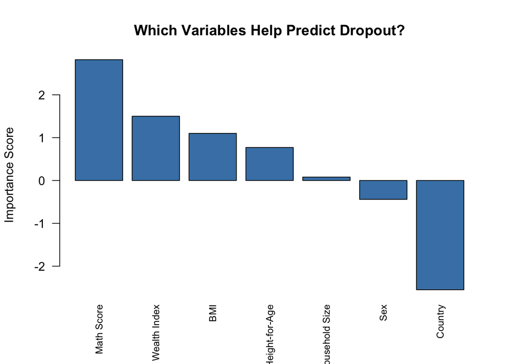

Variable Importance Rankings

**Note:** Negative importance scores for Sex and Country indicate these control variables contribute less to prediction accuracy. The focus should be on our five main predictors: Math Score, Wealth Index, BMI, Height-for-Age, and Household Size.

**Why we include this section:**

Without variable importance, we only know that our model can predict dropout with 40% recall. But we don’t know which variables are driving those predictions. This section shows us which of our 5 predictors (BMI, household size, wealth, math, height-for-age) actually matter for identifying at risk students.

## 3.4 Stage 3: Policy Simulation via Sensitivity Analysis

We were curious to understand how dropout rates would vary as other factors changed. Using a balanced random forest model to address class imbalance, we generate counterfactual scenarios by only changing our variable of interest (body mass index (BMI), household size, household wealth, and math achievement) while leaving all other characteristics unchanged. For each scenario, we recompute predicted dropout probabilities for the full sample and compare the average predicted dropout rate to the baseline.

### 3.4.1 What Are We Testing?

We ask “what if” questions like: - What if we improved kids’ nutrition (BMI increases by 10%)? - What if families were smaller (household size decreases by 2)? - What if tutoring programs raised math scores by 5 points?

For each scenario, we change just one thing and see how the model’s dropout predictions change. This helps us understand which interventions might have the biggest impact.

**One important note:** These are the model’s predictions based on patterns it found in the data. They’re not guaranteed to be what would actually happen with real programs. Think of them as educated guesses that can guide where to focus policy efforts.

```r
library(dplyr)
library(randomForest)


# 1. BALANCE DATA
train_dropout_all <- model_data[model_data$dropout == 1, ]
train_no_dropout_all <- model_data[model_data$dropout == 0, ]

# Downsample non-dropout to match dropout count * 3
set.seed(1234)
train_no_dropout_sampled <- train_no_dropout_all[
  sample(nrow(train_no_dropout_all), nrow(train_dropout_all) * 3),
]

model_data_balanced <- rbind(
  train_dropout_all,
  train_no_dropout_sampled
)

# 2. RANDOM FOREST MODEL

rf_model <- randomForest(
  dropout ~ bmi + hhsize + wi + math + zhfa + sex + country,
  data = model_data_balanced,
  ntree = 500,
  importance = TRUE
)


# 3. BASELINE PREDICTIONS
baseline_pred <- predict(rf_model, model_data, type = "prob")[,2]
baseline_rate <- mean(baseline_pred)


# 4. BMI SCENARIOS
scenario_bmi_5 <- model_data %>% mutate(bmi = bmi * 1.05)
rate_bmi_5 <- mean(predict(rf_model, scenario_bmi_5, type = "prob")[,2])

scenario_bmi_10 <- model_data %>% mutate(bmi = bmi * 1.10)
rate_bmi_10 <- mean(predict(rf_model, scenario_bmi_10, type = "prob")[,2])

scenario_bmi_neg10 <- model_data %>% mutate(bmi = bmi * 0.90)
rate_bmi_neg10 <- mean(predict(rf_model, scenario_bmi_neg10, type = "prob")[,2])


# 5. HOUSEHOLD SIZE SCENARIOS

scenario_hhsize_minus1 <- model_data %>%
  mutate(hhsize = pmax(1, hhsize - 1))
rate_hhsize_minus1 <- mean(
  predict(rf_model, scenario_hhsize_minus1, type = "prob")[,2]
)

scenario_hhsize_minus2 <- model_data %>%
  mutate(hhsize = pmax(1, hhsize - 2))
rate_hhsize_minus2 <- mean(
  predict(rf_model, scenario_hhsize_minus2, type = "prob")[,2]
)

scenario_hhsize_plus1 <- model_data %>%
  mutate(hhsize = hhsize + 1)
rate_hhsize_plus1 <- mean(
  predict(rf_model, scenario_hhsize_plus1, type = "prob")[,2]
)

# 6. MATH SCENARIOS

rate_math_minus5 <- mean(
  predict(
    rf_model,
    model_data %>% mutate(math = math - 5),
    type = "prob"
  )[,2]
)

rate_math_plus5 <- mean(
  predict(
    rf_model,
    model_data %>% mutate(math = math + 5),
    type = "prob"
  )[,2]
)

rate_math_plus10 <- mean(
  predict(
    rf_model,
    model_data %>% mutate(math = math + 10),
    type = "prob"
  )[,2]
)


# 7. WEALTH (WI) SCENARIO
# Wealth +0.5 SD AND Math +5

rate_wi_minus05 <- mean(
  predict(
    rf_model,
    model_data %>% mutate(wi = wi - 0.5),
    type = "prob"
  )[,2]
)

rate_wi_plus05 <- mean(
  predict(
    rf_model,
    model_data %>% mutate(wi = wi + 0.5),
    type = "prob"
  )[,2]
)

rate_wi_plus1 <- mean(
  predict(
    rf_model,
    model_data %>% mutate(wi = wi + 1),
    type = "prob"
  )[,2]
)

# 7. FINAL SENSITIVITY TABLE
sensitivity_results <- data.frame(
  Scenario = c(
    "Baseline",
    "BMI -10%", "BMI +5%", "BMI +10%",
    "HH size -2", "HH size -1", "HH size +1",
    "Wealth -0.5 SD", "Wealth +0.5 SD", "Wealth +1 SD",
    "Math -5 points", "Math +5 points", "Math +10 points"
  ),
  Dropout_Rate = c(
    baseline_rate,
    rate_bmi_neg10, rate_bmi_5, rate_bmi_10,
    rate_hhsize_minus2, rate_hhsize_minus1, rate_hhsize_plus1,
    rate_wi_minus05, rate_wi_plus05, rate_wi_plus1,
    rate_math_minus5, rate_math_plus5, rate_math_plus10
  ),
  Variable = c(
    "Baseline",
    "BMI", "BMI", "BMI",
    "Household Size", "Household Size", "Household Size",
    "Wealth Index", "Wealth Index", "Wealth Index",
    "Math Score", "Math Score", "Math Score"
  )
)

sensitivity_results$Change_from_Baseline <-
  (sensitivity_results$Dropout_Rate - baseline_rate) * 100
```

Sensitivity Analysis: Predicted Impact of Changing Risk Factors

[output not shown]

[figure not shown]

The simulation analysis evaluates how predicted dropout rates change in response to plausible positive and negative shifts in key child and household characteristics, holding the trained model fixed.

- Predicted dropout is most sensitive to household wealth, with negative wealth shocks producing the largest increases in dropout risk and wealth improvements generating substantial reductions.
- Academic performance (math scores) also shows a strong association with dropout risk.
- Nutritional status (BMI) matters, particularly on the downside, as reductions in BMI lead to notable increases in predicted dropout risk.
- Changes in household size have comparatively smaller and less consistent effects on predicted dropout.
- These results are descriptive rather than causal but provide useful insight into which factors the model identifies as most closely associated with school dropout risk.

## 3.5 Policy Recommendations

Based on our analysis, here’s what we think could actually help reduce dropout:

**One policy** implication from our results is to invest in targeted learning acceleration before and during the transition to lower secondary, because math achievement is the strongest and most consistent early-warning predictor of dropout in our models. A scalable approach is structured tutoring that groups students by learning level and teaches foundational numeracy directly, rather than relying on grade-level pacing for everyone. Rigorous evidence from India shows that Teaching at the Right Level-style interventions can generate large learning gains when implemented systematically at scale (Banerjee et al., 2016; J-PAL, 2022).

**Second policy** recommendation is to reduce household financial pressure that pushes adolescents out of school by expanding targeted cash support (scholarships or cash transfers), especially around secondary-school ages. This aligns with our sensitivity analysis, where predicted dropout is most responsive to changes in wealth. Evidence from Mexico’s Progresa/Oportunidades shows meaningful improvements in schooling outcomes such as enrollment and grade progression, consistent with the idea that reducing the direct and opportunity costs of schooling can keep students in school longer (Behrman et al., 2009; Schultz, 2004). Evidence from Brazil also suggests conditional cash transfer programs can improve enrollment and reduce dropout-related outcomes (Glewwe & Kassouf, 2012).

**Finally**, we recommend bundling school-based nutrition and basic child health supports (e.g., meals and deworming), particularly for disadvantaged students, since nutrition shocks in our simulations increase predicted dropout and nutrition/health plausibly support learning readiness. A randomized evaluation in Kenya found subsidized school meals increased school participation, and experimental evidence on school-based deworming shows reductions in absenteeism and improvements in participation in high-burden settings (Miguel & Kremer, 2004; Vermeersch & Kremer, 2004). Together, these packages can stabilize attendance while also complementing learning-focused interventions.

## 3.6 Limitations

1. **Study attrition:**

A key limitation of this study is the high level of attrition across survey round. Attrition of this magnitude raises concerns about sample selection and the external validity of the results, as children who drop out of the study may differ systematically from those who remain (Bamer et al., 2020).

Attrition is unlikely to be random in this context. Children who are poorer, in worse health, or experiencing educational disruption are plausibly more likely both to exit the survey and to drop out of school. If so, the observed sample may overrepresent relatively advantaged children and understate the true prevalence and severity of school dropout. Such systematic attrition can bias estimates and predictive relationships if the mechanisms driving survey attrition are correlated with the outcomes or covariates of interest.

Despite these concerns, we proceed with the analysis for two reasons.

First, the primary objective of the study is predictive and descriptive rather than causal, focusing on identifying correlates of dropout risk and assessing model sensitivity rather than estimating population level treatment effects.

Second, attrition is a well-documented feature of long running longitudinal surveys, and the retained sample remains large and information rich, allowing for meaningful analysis of patterns.

2. **Dropout rate :**

A second limitation in this research is the relatively low incidence of school dropout in the observed sample, which results in a highly imbalanced outcome variable. This leads to our predictive model performing well in terms of overall accuracy while failing to adequately identify individuals at higher risk of dropout (Gandler, 2020).

Class imbalance can lead models to place disproportionate weight on the majority (non-dropout) group, increasing the risk that patterns associated with dropout are underrepresented or unstable (Ibid.). To address this concern, we estimate multiple predictive models that explicitly account for imbalance, including a standard random forest as a baseline, a weighted random forest that penalizes misclassification of dropout cases more heavily, and a balanced random forest that down-samples the majority class during training. We also estimate logistic regression models as a benchmark and use simulation-based sensitivity analysis to examine how predicted dropout probabilities respond to changes in key covariates rather than relying solely on classification outcomes.

Despite these adjustments, the low prevalence of dropout remains a constraint. The results should therefore be interpreted as indicative of relative risk patterns rather than precise predictions.This also means that the outcomes within this research are not generalisable. We proceed with this approach because the goal of the study is to explore predictive correlates and model responsiveness in a low-dropout context, rather than to optimize classification performance or estimate causal effects.

## 3.7 Conclusion

Our research had three separate components : The logit model, our predictive modeling and our simulation modeling. From the logit model, we found that both the math score and the wealth index were important for predicting the dropout. The random forest modeling results echo this as it shows that the math score is the most important predictor for dropout. This is followed by the wealth index and BMI. The simulation further enforces the central role of economics and health by showing that changes in wealth have the largest impact on dropout rates, followed by BMI and math scores. Taken together, these results highlight the consistent importance of wealth, health and academic factors across modeling approaches. In response to this research, we recommend a) targeted learning acceleration during the transition to secondary school b) expanded targeted cash support programs c) bundling school nutrition and basic health support for disadvantaged students. We believe that all three of these solutions will be key reducing dropout rates for children in both India and Peru.

## 3.8 Bibliography

Alderman, H., Behrman, J. R., Kohler, H.-P., Maluccio, J. A., & Watkins, S. C. (2001). Attrition in longitudinal household survey data: Some tests for three developing-country samples. *Demographic Research, 5*, Article 4. https://www.demographic-research.org/volumes/vol5/4/5-4.pdf

Bamer, A. M., McMullen, K., Gibran, N., Holavanahalli, R., Schneider, J. C., Carrougher, G. J., Wiechman, S., Wolfe, A., & Amtmann, D. (2020). Factors associated with attrition of adult participants in a longitudinal database: A National Institute on Disability, Independent Living, and Rehabilitation Research Burn Model System Study. *Journal of Burn Care & Research, 41*(2), 270–279. https://doi.org/10.1093/jbcr/irz186

Banerjee, A., Banerji, R., Berry, J., Duflo, E., Kannan, H., Mukerji, S., Shotland, M., & Walton, M. (2016). *Mainstreaming an effective intervention: Evidence from randomized evaluations of “Teaching at the Right Level” in India* (Working Paper No. 22746). National Bureau of Economic Research.

Behrman, J. R., Parker, S. W., & Todd, P. E. (2009). Schooling impacts of conditional cash transfers on young children: Evidence from Mexico. *Economic Development and Cultural Change, 57*(3), 439–477.

Bisset, S., Fournier, M., Janosz, M., & Pagani, L. (2013). Predicting academic and cognitive outcomes from weight status trajectories during childhood. *International Journal of Obesity, 37*, 1–8. https://doi.org/10.1038/ijo.2012.106

Cahuana Lipa, R., Perez Ccasa, M. E., Machaca Mamani, J. C., Perez Ccasa, E., & Cárdenas Solano, J. (2024). Conditional cash transfer program, child malnutrition and school dropout in the high Andean region of Peru. *Sapienza: International Journal of Interdisciplinary Studies, 5*(4), e24063. https://doi.org/10.51798/sijis.v5i4.830

Chawla, N. V., Bowyer, K. W., Hall, L. O., & Kegelmeyer, W. P. (2002). SMOTE: Synthetic minority over-sampling technique. *Journal of Artificial Intelligence Research, 16*, 321–357.

Chen, C., Liaw, A., & Breiman, L. (2004). *Using random forest to learn imbalanced data*. University of California, Berkeley.

Deveaux, M. (2021, February 23). 4 classification algorithms to deal with unbalanced datasets. *Medium*. https://marc-deveaux.medium.com/4-classification-algorithms-to-deal-with-unbalanced-datasets-d034f575cd6a

Francess, D., Azumah, F., Adjei, E., & Nachinaab, J. (2017). The effects of family size on the investment of child education, case study at Atonsu-Buokro, Kumasi.

Gansaonré, R., Moore, L., Bleau, L.-P., Kobiane, J.-F., & Haddad, S. (2021). Stunting, age at school entry and academic performance in developing countries: A systematic review and meta-analysis. https://doi.org/10.21203/rs.3.rs-606866/v1

Hastie, T., Tibshirani, R., & Friedman, J. H. (2009). *The elements of statistical learning: Data mining, inference, and prediction* (2nd ed.). Springer.

He, H., & Garcia, E. A. (2009). Learning from imbalanced data. *IEEE Transactions on Knowledge and Data Engineering, 21*(9), 1263–1284.

Kuhn, M., & Johnson, K. (2013). *Applied predictive modeling*. Springer.

Machine learning predicts upper secondary education dropout as early as the end of primary school. (2024). *Scientific Reports*. https://www.nature.com/articles/s41598-024-63629-0

Miguel, E., & Kremer, M. (2004). Worms: Identifying impacts on education and health in the presence of treatment externalities. *Econometrica, 72*(1), 159–217.

National Dropout Prevention Center/Network. (2002). *How to identify students at risk of dropping out*. https://dropoutprevention.org/wp-content/uploads/2015/10/SS02HowtoIdentify.pdf

Ozturk, I. (2001). The role of education in economic development: A theoretical perspective. *SSRN Electronic Journal*. https://doi.org/10.2139/ssrn.1137541

Schultz, T. P. (2004). School subsidies for the poor: Evaluating a Mexican strategy for reducing poverty. *Journal of Development Economics, 74*(2), 199–250.

UK Data Service. (n.d.). *Data catalogue series 2000060*. https://datacatalogue.ukdataservice.ac.uk/series/series/2000060

UNESCO. (2021). *Global education monitoring report 2021/2: Non-state actors in education: Who chooses? Who loses?* UNESCO Publishing. https://unesdoc.unesco.org/ark:/48223/pf0000379875

UNICEF. (2022). *Secondary education*. https://data.unicef.org/topic/education/secondary-education/

Vermeersch, C., & Kremer, M. (2004). *School meals, educational achievement and school competition: Evidence from a randomized evaluation* (Policy Research Working Paper No. 3523). World Bank.

Wangu, G. J., Odek, A., & Marima, E. (2024). Social-economic factors and secondary school dropout among girls in Mariani Ward, Tharaka-Nithi County, Kenya. *African Journal of Empirical Research, 5*(4), 520–534. https://ajernet.net

World Bank. (2009). *Conditional cash transfers: Reducing present and future poverty*. Washington, DC: World Bank. https://openknowledge.worldbank.org/server/api/core/bitstreams/c9f76e5b-ac70-50c0-ac1e-aec104bff356/content

Young Lives. (n.d.). *Data and research*. https://www.younglives.org.uk/data-research

Zarzar Gandler, G. (2020, October 7). Training models on imbalanced data. *Towards Data Science*. https://towardsdatascience.com/training-models-on-imbalanced-data-561fa3f842b5